# 🎬 ReelShort データ分析ノートブック

このノートブックでは、ReelShortの全作品データを分析・可視化します。

## 目次

1. データ読み込みと前処理
2. 基本統計
3. 再生数分析
4. 地域・カテゴリ分析
5. 時系列分析
6. 日本人キャスト作品分析
7. タグ分析
8. ワードクラウド
9. 相関分析

## 1. データ読み込みと前処理

```
✅ Plotly利用可能 - インタラクティブグラフが使えます
ライブラリ読み込み完了！
```

```
ヘルパー関数定義完了！
```

```
📁 読み込んだ作品数: 1026
✅ DataFrame作成完了: 1026行 x 16列
```

|  | book_id | t_book_id | title | read_count | collect_count | chapter_count | release_date | special_desc | tags | category | region | is_japanese_cast | year_month | year | month | read_count_log |
| --- | --- | --- | --- | --- | --- | --- | --- | --- | --- | --- | --- | --- | --- | --- | --- | --- |
| 0 | 6901b1f0e12f46f83f05026d | 140000000000000355 | おかえりパパとママだよ | 39454 | 673 | 27 | 2025-10-29 15:19:28 | 大学一年生の娘が、家族恒例の感謝祭を祝うために久しぶりに帰省する。\nしかし、彼女は両親の様... | [サスペンス] | 日本語吹き替え版 | 日本 | False | 2025-10 | 2025 | 10 | 4.596091 |
| 1 | 6854d0b61cc7f0fc460aa3a1 | 140000000000000272 | 人を呪わば穴二つ | 589496 | 41038 | 30 | 2025-06-20 12:08:38 | 専業主婦カレン、夫のトムはお金持ちの弁護士だった。ある日カレンが外出中、自宅が火災に遭い、5... | [女性向けのドラマ, ドラマ, 復讐, 浮気, 隣人, 家庭主婦] | 日本語吹き替え版 | 日本 | False | 2025-06 | 2025 | 6 | 5.770481 |
| 2 | 684a3c59bf0dba6aa601c07a | 140000000000000257 | 調停者 | 291720 | 25645 | 38 | 2025-06-12 11:32:57 | 妹が保険を失い命を落としたその日から、マッテオ・レオーネの人生は一変した。絶望の中で、彼は保... | [男向けのドラマ, 復讐, モダン, 守る夫, 医者] | 日本語吹き替え版 | 日本 | False | 2025-06 | 2025 | 6 | 5.464966 |
| 3 | 686f5afe374f7f776f0f5956 | 140000000000000279 | 空飛ぶ修羅場 | 3768813 | 86860 | 41 | 2025-07-10 15:17:34 | 足を骨折しギプスを装着中のイヴは、ハワイで行われる兄の結婚式に出席するため、広めの座席を予約... | [復讐] | 日本語吹き替え版 | 日本 | False | 2025-07 | 2025 | 7 | 6.576205 |
| 4 | 68d2060f4d6ba943670b0645 | 140000000000000334 | 偽りのルナと運命のつがい | 37896 | 488 | 44 | 2025-09-23 11:29:35 | 彼は彼女を救うため、残忍な父を殺した。新たなアルファキングとなった彼は、運命のメイトを生かす... | [復讐] | 日本語吹き替え版 | 日本 | False | 2025-09 | 2025 | 9 | 4.578593 |

## 2. 基本統計

```
============================================================
📊 基本統計情報
============================================================
  総作品数: 1.0K (1,026)
  総再生数: 1436.1M (1,436,146,756)
  総いいね数: 18.4M (18,402,161)
  平均再生数: 1.4M (1,399,753)
  中央値再生数: 492.4K (492,423)
  最大再生数: 21.7M (21,710,063)
  平均エピソード数: 70 (70)
  日本人キャスト作品数: 17 (17)

🏆 再生数TOP5:
     21.7M | ［吹き替え］私こそが学園のクイーン・ビー (日本向け（プレミアム）)
     20.5M | あなたと出会う運命 (日本語吹き替え版)
     17.7M | 私こそが学園のクイーン・ビー (日本語吹き替え版)
     17.7M | 労働者父が大富豪？！ (中国語圏)
     16.5M | ホームレスの夫が実は大富豪 ～クリスマスの奇跡～ (日本語吹き替え版)
```

## 3. 再生数分析

[interactive chart not shown]

## 4. 地域・カテゴリ分析

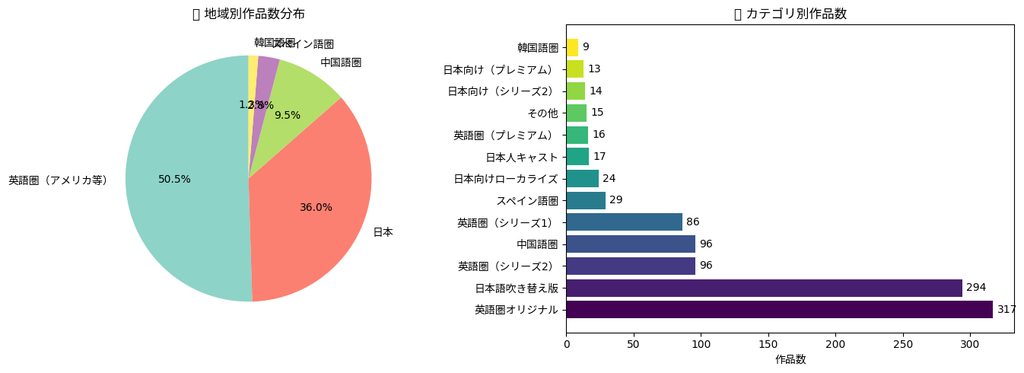

## 5. 時系列分析

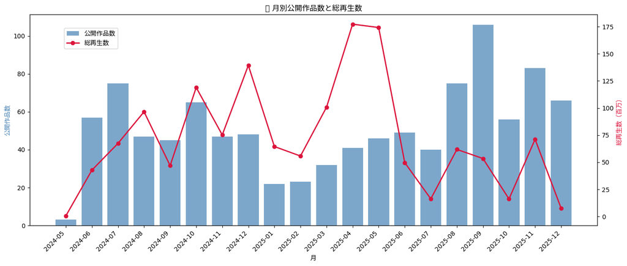

## 6. 日本人キャスト作品分析 🇯🇵

```
🇯🇵 日本人キャスト日本オリジナル作品: 17作品
   総再生数: 94.7M
   平均再生数: 5.6M

【再生数ランキング】
----------------------------------------------------------------------
 1.    14.3M | 令嬢決戦！私こそが学園のクイーン                    | 2025-04-16
 2.    11.6M | ダイヤモンドの再会                           | 2024-12-03
 3.    10.9M | 冷酷御曹司の愛妻計画                          | 2025-04-25
 4.    10.7M | 財閥令嬢様の二重生活                          | 2024-12-10
 5.     9.0M | 嫌いなアイツの専属メイド!?                      | 2025-05-20
 6.     8.4M | 銃と金とクリスマス                           | 2025-05-09
 7.     6.7M | せめて最後に愛のキスを                         | 2025-01-13
 8.     5.3M | 無職の夫は大富豪だった件!                       | 2025-03-14
 9.     3.8M | 消防士の元夫、悔恨の炎に焼かれて                    | 2025-06-30
10.     3.3M | 帰ってきたお嬢様                            | 2025-01-13
11.     2.2M | 一目惚れ！今すぐ結婚してくれますか？                  | 2025-04-08
12.     2.1M | ケーキ職人のワタシが大富豪と偽装結婚した話               | 2025-04-16
13.     1.8M | もう一度、君に恋をする                         | 2025-04-12
14.     1.5M | 負け犬の私がバージンを捨てる！                     | 2025-05-09
15.     1.3M | 禁断の誘い～彼のものに～                        | 2025-05-06
16.     1.3M | Yesから始まるラブストーリー                     | 2024-12-03
17.   513.9K | 奪われたプリマバレリーナ                        | 2025-04-12
```

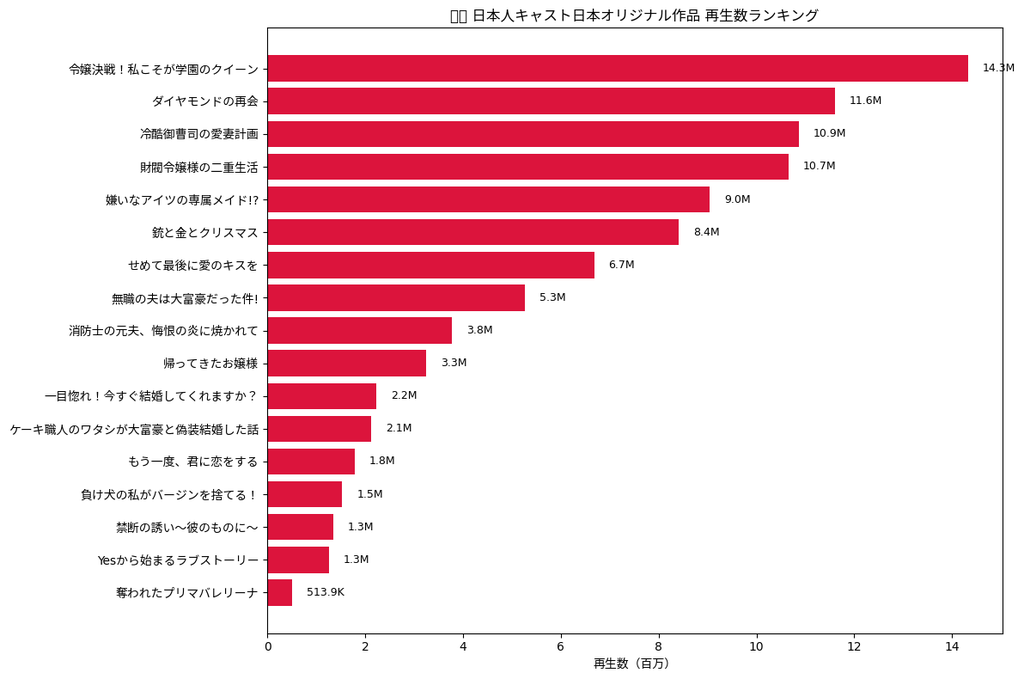

## 7. タグ分析

```
📌 ユニークタグ数: 202
```

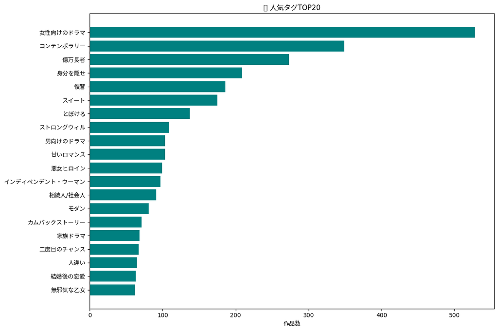

## 8. ワードクラウド

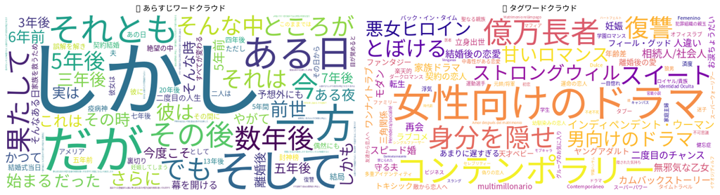

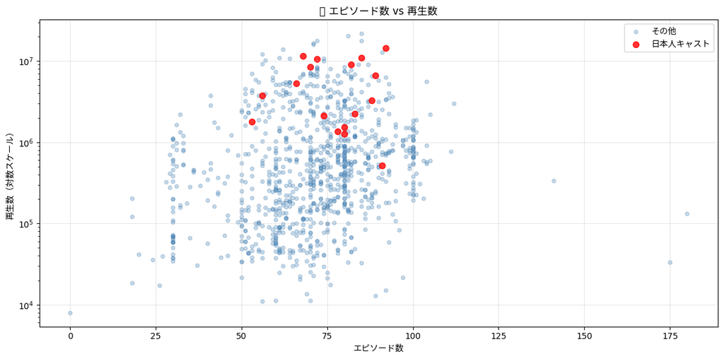

```
相関係数:
  再生数 vs エピソード数: 0.087
  再生数 vs いいね数: 0.898
```

[interactive chart not shown]

## 10. 英語版 vs 日本語版 比較分析 🌍

英語版ReelShort（1,827作品）と日本語版（1,026作品）を比較分析します。

### 英語版コンテンツの種類

| プレフィックス | カテゴリ | 特徴 |
| --- | --- | --- |
| `209000000000000` | 🇺🇸 オリジナル（新） | アメリカ制作の新シリーズ |
| `200000000000000` | 🇺🇸 オリジナル（旧） | クラシック作品 |
| `209001XXXXXXXXX` | 🔊 吹き替え版 | 中国等からの吹き替え |
| `200000200000000` | ⭐ プレミアム | 高品質コンテンツ |
| `200000800000000` | 📺 ReelTalk | トーク番組 |

```
✅ 英語版データ: 1827作品
📊 英語版DataFrame: 1827行
```

```
📊 英語版 vs 日本語版 統計比較
======================================================================
   項目         🇺🇸 英語版       🇯🇵 日本語版    倍率
  作品数          1,827         1,026  1.8x
 総再生数 24,194,833,072 1,436,146,756 16.8x
 総いいね    244,850,646    18,402,161 13.3x
平均再生数     13,242,930     1,399,753  9.5x
  中央値      1,307,763       492,423  2.7x
最大再生数    503,653,071    21,710,063 23.2x
```

[interactive chart not shown]

```
📊 英語版 コンテンツ種類別統計
================================================================================
🇺🇸 オリジナル           |  1381作品 | 総再生: 21,561,012,324 | 平均: 15,612,608
✨ 特別コンテンツ          |   214作品 | 総再生: 1,220,700,492 | 平均:  5,704,208
⭐ プレミアム            |    27作品 | 総再生:   783,827,109 | 平均: 29,030,634
📦 その他              |    96作品 | 総再生:   400,761,596 | 平均:  4,174,600
🔊 吹き替え版            |    62作品 | 総再生:   207,728,977 | 平均:  3,350,467
📺 ReelTalk         |    47作品 | 総再生:    20,802,574 | 平均:    442,608
```

[interactive chart not shown]

```
📊 コンテンツ種類別統計:
  🇺🇸 英語版: 1,827作品, 平均再生数: 13,242,930
  🇯🇵 RSオリジナル日本ドラマ: 17作品, 平均再生数: 5,568,010
  🇯🇵 日本語版（吹き替え等）: 1,009作品, 平均再生数: 1,329,525
```

```
📊 オリジナル vs 吹き替え版
======================================================================
項目                        🇺🇸 オリジナル            🔊 吹き替え版
----------------------------------------------------------------------
作品数                          1,381                 62
総再生数                21,561,012,324        207,728,977
平均再生数                   15,612,608          3,350,467

🔊 吹き替え版 TOP5:
  1. 11,647,647 | I Gave My wife A Red Tasseled Spear (English-
  2. 11,376,954 | CEO, That Intern is Actually Your Wife (Engli
  3. 10,560,565 | Sweet Debt, Secret Billionaire (English-dubbe
  4.  9,727,902 | The Wife I Despised Is My First Love?! (Engli
  5.  9,412,331 | Marrying A Millionaire with My Baby (English-
```

[interactive chart not shown]

```
📊 カテゴリ別統計:
```

| category | 作品数 | 総再生数 | 平均再生数 | 総いいね | 平均EP |
| --- | --- | --- | --- | --- | --- |
| 英語圏オリジナル | 317 | 256422808 | 808905.0 | 1665029 | 77.0 |
| 日本語吹き替え版 | 294 | 770019882 | 2619115.0 | 11851533 | 71.0 |
| 英語圏（シリーズ2） | 96 | 19367579 | 201746.0 | 212246 | 71.0 |
| 中国語圏 | 96 | 83080842 | 865425.0 | 1123177 | 50.0 |
| 英語圏（シリーズ1） | 86 | 45353234 | 527363.0 | 290116 | 77.0 |
| スペイン語圏 | 29 | 6108345 | 210633.0 | 83858 | 55.0 |
| 日本向けローカライズ | 24 | 27899220 | 1162468.0 | 555589 | 70.0 |
| 日本人キャスト | 17 | 94656175 | 5568010.0 | 939190 | 77.0 |
| 英語圏（プレミアム） | 16 | 31417328 | 1963583.0 | 254900 | 65.0 |
| その他 | 15 | 28781922 | 1918795.0 | 500309 | 58.0 |
| 日本向け（シリーズ2） | 14 | 926581 | 66184.0 | 11666 | 66.0 |
| 日本向け（プレミアム） | 13 | 66767498 | 5135961.0 | 854078 | 71.0 |
| 韓国語圏 | 9 | 5345342 | 593927.0 | 60470 | 46.0 |

```
💡 データをエクスポートするには、上のコメントを外して実行してください
```

## 11. テキストマイニング比較（日本語版 vs 英語版）📝

日本語版と英語版のタイトル・タグ・あらすじを比較分析します。

```
📊 タグ頻度比較 TOP 20
======================================================================
🇯🇵 日本語版                             | 🇺🇸 英語版
----------------------------------------------------------------------
女性向けのドラマ: 528                       | Female: 941
コンテンポラリー: 349                       | Contemporary: 758
億万長者: 273                           | Billionaire: 518
身分を隠せ: 209                          | Revenge: 412
復讐: 186                             | Sweet: 353
スイート: 175                           | Hidden Identity: 347
とぼける: 137                           | Strong-Willed: 241
ストロングウィル: 109                       | Independent Woman: 226
男向けのドラマ: 103                        | Playing Dumb: 217
甘いロマンス: 103                         | Male: 211
悪女ヒロイン: 99                          | Strong Heroine: 183
インディペンデント・ウーマン: 97                  | Family Drama: 161
相続人/社会人: 91                         | Heiress/Socialite: 150
モダン: 81                             | Sweet Romance: 149
カムバックストーリー: 71                      | Love After Marriage: 143
家族ドラマ: 68                           | Second Chance: 124
二度目のチャンス: 67                        | One Night Stand: 116
人違い: 65                             | Innocent Damsel: 112
結婚後の恋愛: 63                          | Mistaken Identity: 107
無邪気な乙女: 62                          | Reunion: 106
```

[interactive chart not shown]

```
🇺🇸 英語版タイトル 頻出単語 TOP 30
==================================================
love             215 █████████████████████
ceo              129 ████████████
billionaire      108 ██████████
wife             101 ██████████
you               93 █████████
husband           88 ████████
heiress           75 ███████
after             71 ███████
english           62 ██████
dubbed            62 ██████
reeltalk          56 █████
boss              47 ████
secret            46 ████
back              45 ████
daddy             45 ████
revenge           44 ████
your              43 ████
bride             42 ████
baby              39 ███
married           36 ███
reborn            35 ███
divorce           34 ███
marriage          33 ███
dad               32 ███
one               30 ███
king              29 ██
from              29 ██
life              28 ██
mom               28 ██
alpha             26 ██
```

```
🇯🇵 日本語版タイトル キーワード出現頻度
==================================================
愛            136 ██████████████████████████████
恋             90 ██████████████████████████████
夫             61 ██████████████████████████████
運命            47 ██████████████████████████████
結婚            46 ██████████████████████████████
妻             46 ██████████████████████████████
億万長者          42 ██████████████████████████████
令嬢            41 ██████████████████████████████
復讐            34 ██████████████████████████████
秘密            34 ██████████████████████████████
CEO           31 ██████████████████████████████
離婚            23 ███████████████████████
大富豪           23 ███████████████████████
契約            23 ███████████████████████
再会            16 ████████████████
アルファ          16 ████████████████
御曹司           14 ██████████████
偽装             8 ████████
嘘              7 ███████
初恋             7 ███████
裏切り            6 ██████
王子             5 █████
狼              5 █████
シンデレラ          3 ███
```

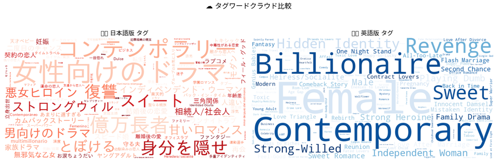

```
⚠️ 英語版あらすじデータがありません
```

```
======================================================================
📊 テキストマイニング分析 サマリー
======================================================================

🇯🇵 日本語版:
  作品数: 1,026
  ユニークタグ数: 202
  最頻出タグ: [('女性向けのドラマ', 528), ('コンテンポラリー', 349), ('億万長者', 273), ('身分を隠せ', 209), ('復讐', 186)]

🇺🇸 英語版:
  作品数: 1,827
  ユニークタグ数: 211
  最頻出タグ: [('Female', 941), ('Contemporary', 758), ('Billionaire', 518), ('Revenge', 412), ('Sweet', 353)]

📝 主な発見:
  - 日本語版: ロマンス・億万長者系が人気
  - 英語版: Fantasy/Werewolf系コンテンツが豊富
  - 両言語共通: CEO/Billionaireテーマが定番
```

## 12. 損益分岐点分析 💰

制作費2000万円を前提に、日本市場での収益シミュレーションを行います。

### 前提条件

- **制作費**: 2,000万円
- **広告費**: 0〜2,000万円（シナリオ別）
- **1話あたり課金**: 60コイン = 90円（1300コイン=$13 @150円/ドル）
- **広告収入**: 無料話視聴1回あたり1円
- **プラットフォーム手数料**: 30%

### 分析変数

- **課金率**: 視聴者のうち課金する人の割合（1-7%で分析）

```
📊 パラメータ設定完了
  制作費: 2,000万円

💰 課金モデル:
  1話課金: 60コイン = 90円
  課金者平均購入: 15話 = 1,350円/人
  広告収入: 1円/視聴
  手数料: 30%

📈 課金率シナリオ: ['1%', '2%', '3%', '4%', '5%', '6%', '7%']
```

```
✅ 計算関数定義完了

📌 収益計算式:
  課金収入 = 視聴者 × 課金率 × 15話 × 90円 × 0.7
  広告収入 = 視聴者 × 無料話数 × 1円 × 0.7
```

```
====================================================================================================
📊 シナリオ別 損益分岐点（必要再生数）
====================================================================================================
制作費: 2,000万円 | 課金者平均購入: 15話 × 90円 = 1,350円/人

シナリオ                   | 無料話    | 1% | 2% | 3% | 4% | 5% | 6% | 7% |
----------------------------------------------------------------------------------------------------
シナリオA: 無料5話            | 5      |  7.7M |  4.5M |  3.1M |  2.4M |  2.0M |  1.7M |  1.4M |
シナリオB: 無料10話           | 10     |  6.1M |  3.9M |  2.8M |  2.2M |  1.8M |  1.6M |  1.4M |
シナリオC: 無料15話           | 15     |  5.0M |  3.4M |  2.6M |  2.1M |  1.7M |  1.5M |  1.3M |
シナリオD: 無料20話           | 20     |  4.3M |  3.0M |  2.4M |  1.9M |  1.6M |  1.4M |  1.2M |

📌 RSオリジナル日本ドラマ平均: 約5.6M再生
```

[interactive chart not shown]

```
====================================================================================================
💰 収益シミュレーション（課金率3%、無料10話）
====================================================================================================
制作費: 2,000万円 | 課金者平均: 15話 × 90円 × 0.7 = 945円/人

再生数        | 視聴者        | 課金者        | 課金収入       | 広告収入     | 総収入        | 損益           | ROI
----------------------------------------------------------------------------------------------------
❌ 1.0M      |    20.0万 |    6,000人 |      567万 |    140万 |      707万 | -1,293万      | -65%
✅ 3.0M      |    60.0万 |   18,000人 |    1,701万 |    420万 |    2,121万 | +121万        | +6%
✅ 5.0M      |   100.0万 |   30,000人 |    2,835万 |    700万 |    3,535万 | +1,535万      | +77%
✅ 5.6M      |   112.0万 |   33,600人 |    3,175万 |    784万 |    3,959万 | +1,959万      | +98%
✅ 10.0M      |   200.0万 |   60,000人 |    5,670万 |  1,400万 |    7,070万 | +5,070万      | +254%
```

```
====================================================================================================
📊 課金率別 収益比較（再生数5.6M = RSオリジナル平均）
====================================================================================================
制作費: 2,000万円

課金率      | 視聴者        | 課金者        | 課金収入       | 広告収入     | 総収入        | 損益           | ROI
----------------------------------------------------------------------------------------------------
❌ 1%      |   112.0万 |   11,200人 |    1,058万 |    784万 |    1,842万 | -158万        | -8%
✅ 2%      |   112.0万 |   22,400人 |    2,117万 |    784万 |    2,901万 | +901万        | +45%
✅ 3%      |   112.0万 |   33,600人 |    3,175万 |    784万 |    3,959万 | +1,959万      | +98%
✅ 4%      |   112.0万 |   44,800人 |    4,234万 |    784万 |    5,018万 | +3,018万      | +151%
✅ 5%      |   112.0万 |   56,000人 |    5,292万 |    784万 |    6,076万 | +4,076万      | +204%
✅ 6%      |   112.0万 |   67,200人 |    6,350万 |    784万 |    7,134万 | +5,134万      | +257%
✅ 7%      |   112.0万 |   78,400人 |    7,409万 |    784万 |    8,193万 | +6,193万      | +310%
```

[interactive chart not shown]

```
====================================================================================================
📢 広告費込み 損益分岐点分析（課金率3%、無料10話）
====================================================================================================

広告費          | 総コスト         | 必要再生数        | 必要課金者
--------------------------------------------------------------------------------
広告なし         |      2,000万 |        2.8M |     16,973人
低予算          |      2,500万 |        3.5M |     21,216人
中予算          |      3,000万 |        4.2M |     25,460人
高予算          |      4,000万 |        5.7M |     33,946人
```

[interactive chart not shown]

```
📌 RSオリジナル平均: 5.6M再生
```

```
==========================================================================================
📈 広告投資効果分析（5.6M再生想定）
==========================================================================================

広告費          | 総コスト       | 総収入        | 純利益          | ROI      | 判定
------------------------------------------------------------------------------------------
広告なし         |    2,000万 |    3,959万 | +1,959万      | +98%     | ✅ 黒字
低予算          |    2,500万 |    3,959万 | +1,459万      | +58%     | ✅ 黒字
中予算          |    3,000万 |    3,959万 | +959万        | +32%     | ✅ 黒字
高予算          |    4,000万 |    3,959万 | -41万         | -1%      | ❌ 赤字
```

[interactive chart not shown]

```
📌 緑: 黒字、赤: 赤字
```

[interactive chart not shown]

[output not shown]

```
===============================================================================================
📊 RSオリジナル日本ドラマ 収益推定（課金率3%想定）
===============================================================================================
制作費: 2,000万円 | 課金者平均: 15話購入

タイトル                         | 再生数      | 総収入        | 損益           | ROI
-----------------------------------------------------------------------------------------------
✅ 令嬢決戦！私こそが学園のクイーン           |   14.3M |   10,125万 | +8,125万      | +406%
✅ ダイヤモンドの再会                  |   11.6M |    8,200万 | +6,200万      | +310%
✅ 冷酷御曹司の愛妻計画                 |   10.9M |    7,679万 | +5,679万      | +284%
✅ 財閥令嬢様の二重生活                 |   10.7M |    7,536万 | +5,536万      | +277%
✅ 嫌いなアイツの専属メイド!?             |    9.0M |    6,398万 | +4,398万      | +220%
✅ 銃と金とクリスマス                  |    8.4M |    5,943万 | +3,943万      | +197%
✅ せめて最後に愛のキスを                |    6.7M |    4,723万 | +2,723万      | +136%
✅ 無職の夫は大富豪だった件!              |    5.3M |    3,727万 | +1,727万      | +86%
✅ 消防士の元夫、悔恨の炎に焼かれて           |    3.8M |    2,667万 | +667万        | +33%
✅ 帰ってきたお嬢様                   |    3.3M |    2,301万 | +301万        | +15%
❌ 一目惚れ！今すぐ結婚してくれますか？         |    2.2M |    1,572万 | -428万        | -21%
❌ ケーキ職人のワタシが大富豪と偽装結婚した話      |    2.1M |    1,499万 | -501万        | -25%
❌ もう一度、君に恋をする                |    1.8M |    1,260万 | -740万        | -37%
❌ 負け犬の私がバージンを捨てる！            |    1.5M |    1,082万 | -918万        | -46%
❌ 禁断の誘い～彼のものに～               |    1.3M |      953万 | -1,047万      | -52%
❌ Yesから始まるラブストーリー            |    1.3M |      892万 | -1,108万      | -55%
❌ 奪われたプリマバレリーナ               |    0.5M |      363万 | -1,637万      | -82%

📌 黒字作品: 10/17作品
📌 合計損益: 32,922万円
```

[output not shown]

[output cut: 8 more lines]

[output not shown]

## 13. 日本市場収益分析（制作国別）📊💴

**制作国別**（日本オリジナル/アメリカ制作/中国制作/タイ制作/その他）に分けて、日本市場全体の収益性を分析します。

### 📋 分析の前提条件

| 項目 | 値 | 根拠 |
| --- | --- | --- |
| RSオリジナル日本制作費 | 2,000万円/作品 | 日本での撮影・キャスト費用 |
| アメリカ制作（吹き替え） | 300万円/作品 | 吹き替え+ローカライズ費用 |
| 中国制作（吹き替え） | 300万円/作品 | 吹き替え+ローカライズ費用 |
| タイ制作（吹き替え） | 300万円/作品 | 吹き替え+ローカライズ費用 |
| 1話課金 | 90円 | 60コイン × 1.5円/コイン |
| 課金者平均購入 | 15話 | 推定値 |
| プラットフォーム手数料 | 30% | AppStore/GooglePlay標準 |
| 広告収入 | 1円/視聴 | 推定値 |

### 📊 使用データ

- **データソース**: ReelShort API から取得した日本語版コンテンツ全1,026作品
- **制作国判別**: `t_book_id`の接頭辞パターンで分類
  - `140000000140000...` → 日本オリジナル（17作品）
  - `1400...` → アメリカ制作（352作品）
  - `1490...` → 中国制作（518作品）
  - `1480...` → タイ制作（97作品）
  - その他 → その他アジア

```
📊 日本市場収益分析 パラメータ（制作国別）
============================================================

【制作費設定】
  🇯🇵 日本オリジナル: 2,000万円/作品
  🇺🇸 アメリカ制作: 300万円/作品
  🇨🇳 中国制作: 300万円/作品
  🇹🇭 タイ制作: 300万円/作品
  🌏 その他アジア: 300万円/作品
  🌐 その他: 300万円/作品

【収益パラメータ】
  1話課金: 90円
  課金者平均購入: 15話
  広告収入: 1円/視聴
  手数料: 30%
```

```
📌 日本市場 制作国別分類
======================================================================

【🇯🇵 日本オリジナル】
  作品数: 17作品
  総再生数: 94.7M回
  平均再生数: 5.57M/作品
  制作費: 2,000万円/作品

【🇺🇸 アメリカ制作】
  作品数: 352作品
  総再生数: 889.7M回
  平均再生数: 2.53M/作品
  制作費: 300万円/作品

【🇨🇳 中国制作】
  作品数: 518作品
  総再生数: 354.4M回
  平均再生数: 0.68M/作品
  制作費: 300万円/作品

【🇹🇭 タイ制作】
  作品数: 97作品
  総再生数: 85.4M回
  平均再生数: 0.88M/作品
  制作費: 300万円/作品

【🌏 その他アジア】
  作品数: 29作品
  総再生数: 6.1M回
  平均再生数: 0.21M/作品
  制作費: 300万円/作品

【🌐 その他】
  作品数: 13作品
  総再生数: 5.9M回
  平均再生数: 0.45M/作品
  制作費: 300万円/作品
```

[interactive chart not shown]

```
💡 示唆: 中国制作は作品数が最多(50%)だが、再生数シェアは25%。アメリカ制作は作品数34%で再生数62%と高効率。
```

```
✅ 制作国別収益計算完了（課金率3%）

✅ 🇺🇸 アメリカ制作: 352作品, 損益 +52.3億円, ROI +496%
✅ 🇨🇳 中国制作: 518作品, 損益 +9.5億円, ROI +61%
✅ 🇯🇵 日本オリジナル: 17作品, 損益 +3.3億円, ROI +97%
✅ 🇹🇭 タイ制作: 97作品, 損益 +3.1億円, ROI +107%
✅ 🌐 その他: 13作品, 損益 +0.0億円, ROI +7%
❌ 🌏 その他アジア: 29作品, 損益 -0.4億円, ROI -50%
```

[interactive chart not shown]

[output not shown]

[interactive chart not shown]

[output not shown]

[interactive chart not shown]

```
💡 示唆: 日本オリジナル（赤）は再生数が高く、大半が損益分岐点を超えている。
```

```
==============================================================================================================
📊 制作国別 損益サマリー（課金率3%）
==============================================================================================================

制作国                    |      作品数 |       総再生数 |          制作費 |           収入 |           損益 |      ROI
--------------------------------------------------------------------------------------------------------------
✅ 🇺🇸 アメリカ制作            |     352作品 |      890M |       10.6億 |       62.9億 |       +52.3億 |   +496%
✅ 🇨🇳 中国制作              |     518作品 |      354M |       15.5億 |       25.1億 |        +9.5億 |    +61%
✅ 🇯🇵 日本オリジナル           |      17作品 |       95M |        3.4億 |        6.7億 |        +3.3億 |    +97%
✅ 🇹🇭 タイ制作              |      97作品 |       85M |        2.9億 |        6.0億 |        +3.1億 |   +107%
✅ 🌐 その他                |      13作品 |        6M |        0.4億 |        0.4億 |        +0.0億 |     +7%
❌ 🌏 その他アジア             |      29作品 |        6M |        0.9億 |        0.4億 |        -0.4億 |    -50%
--------------------------------------------------------------------------------------------------------------
📊 合計                   |    1026作品 |     1436M |       33.7億 |      101.5億 |       +67.9億 |   +202%
```

```
==========================================================================================
📋 日本市場収益分析 結論と示唆
==========================================================================================

【市場全体】
  ✅ 日本市場全体は課金率3%で +67.9億円の黒字
  ✅ 市場全体ROI: +202%

【制作国別 示唆】

  🇺🇸 アメリカ制作（352作品）
    ・平均再生数 2.5M/作品で収益の柱
    ・吹き替え費用300万円に対しROI +496%
    → アメリカのヒット作を積極的にローカライズすべき

  🇨🇳 中国制作（518作品）
    ・作品数は最多だが、平均再生数 0.68M/作品と低め
    ・ROI +61%と効率は悪くない
    → 選別的なローカライズで効率化の余地あり

  🇯🇵 日本オリジナル（17作品）
    ・平均再生数 5.6M/作品と高パフォーマンス
    ・制作費2000万円でもROI +97%と投資価値あり
    → 日本市場向けオリジナルコンテンツの拡大が有効

  🇹🇭 タイ制作（97作品）
    ・一部の作品が高パフォーマンス
    ・ROI +107%と効率的
    → ヒット作の選別ローカライズが有効

  🌐 その他（13作品）
    ・ROI +7%

  🌏 その他アジア（29作品）
    ・ROI -50%

【戦略的提言】
  1️⃣  日本オリジナル制作を継続・拡大（高パフォーマンス、ブランド価値）
  2️⃣  アメリカ制作のヒット作を優先的にローカライズ（最高収益）
  3️⃣  中国制作は選別的に（全作品のローカライズは非効率）
  4️⃣  課金率向上施策（3%→5%で利益2倍）が最も効果的
  5️⃣  タイ制作もヒット作があれば積極採用
```

```
📊 全1026作品中、公開日あり: 1026作品
公開日範囲: 2024-05-29 02:33:18 〜 2025-12-24 15:38:21
```

[interactive chart not shown]

[output not shown]

```
📊 全1026作品の損益計算完了
```

[interactive chart not shown]

```
📊 損益分析（課金率3%）:
  ✅ 黒字作品: 539作品 (52.5%)
  ❌ 赤字作品: 487作品 (47.5%)
```

[interactive chart not shown]

[output not shown]

[interactive chart not shown]

[output not shown]